# Baseball Salary Analysis

2022-08-05

## Introduction

We will be examining what statistics related to a baseball player’s performance have a significant effect on the salary of a player. This is particularly interesting as it is sort of the flip-side of the coin to the traditional Sabermetrics employed by the Oakland Athletics in the 1990’s to analyze player statistics to try to assemble a winning team. We will be instead be leveraging the dataset to instead work for the players, hopefully determining which statistic(s) a player should focus on improving in order to increase their compensation.

Before we begin our analysis, we must first load the data and other dependencies from their respective libraries:

```r
library(Lahman)
library(knitr)
library(lmtest)
library(scales)
library(ggplot2)
```

Additionally, we will increment all of the numeric variables by one to facilitate log transformations for the predictors:

```r
salary_data[ , ! colnames(salary_data) %in% c("yearID", "lgID", "POS") ] =
  salary_data[ , ! colnames(salary_data) %in% c("yearID", "lgID", "POS") ] + 1
```

Creating CSV to include with assignment submission:

```r
write.csv(salary_data, "salary_data.csv", row.names = FALSE)
```

## Methods

First, we visualize pairwise correlations between `Salary` and other variables:

- Calculating the correlations:

```r
salary_data_plot = as.data.frame(lapply(salary_data, as.integer))
salary_data_cor = cor(salary_data_plot)
```

- Plotting the relationships:

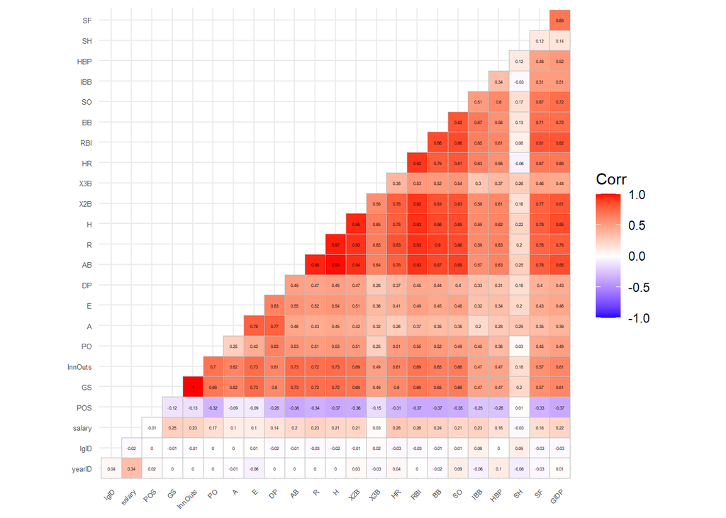

```r
library(ggcorrplot)
my_plt = ggcorrplot(salary_data_cor, lab = TRUE, lab_size = 1, type = "lower")
my_plt + theme(axis.text.x = element_text(size = 5), axis.text.y = element_text(size = 5))
```

Before generating models, we begin by splitting the data into a test and train dataset. For this project we will split 60% of the data into a training set and 40% of the data into a testing set.

```r
salary_data = subset(salary_data, select = -c(InnOuts))
set.seed(20220805)
salary_trn_idx = sample(nrow(salary_data), size = trunc(0.60 * nrow(salary_data)))
salary_trn = salary_data[salary_trn_idx, ]
salary_tst = salary_data[-salary_trn_idx, ]
```

Next, we create a simple additive model with all of the predictors and a model with no predictors:

```r
simple_add = lm(salary ~ ., data = salary_trn)
simple_fit = lm(salary ~ 1, data = salary_trn)
```

We then use AIC and BIC stepwise procedures to refine our model (See appendix):

```r
biggest = formula(lm(salary ~ ., data = salary_trn))
back_aic = step(simple_add, direction = "backward", trace = 0)

n = length(resid(simple_add))
back_bic = step(simple_add, direction = "backward", k = log(n), trace = 0)
```

- Now we can compare the LOOCV RMSE and Adjusted R Squared for both models:

  ```r
  calc_loocv_rmse = function(model) {
    sqrt(mean((resid(model) / (1 - hatvalues(model))) ^ 2))
  }

  rsquared = c(summary(back_aic)$adj.r.squared, summary(back_bic)$adj.r.squared)
  rmse = c(calc_loocv_rmse(back_aic), calc_loocv_rmse(back_bic))
  aic_results = data.frame(Model = c("Backward AIC", "Backward BIC"),
                           AdjR = rsquared, RMSE = rmse)

  kable(aic_results,
        col.names = c("Selection Procedure", "Adjusted R. Squared", "LOOCV RMSE"))
  ```

  | Selection Procedure | Adjusted R. Squared | LOOCV RMSE |
  | --- | --- | --- |
  | Backward AIC | 0.2707598 | 2793220 |
  | Backward BIC | 0.2704224 | 2793664 |

- Although both models have similar Adjusted $R^2$ and LOOCV RMSE values, the BIC model uses fewer predictors:

  ```r
  attr(back_aic$terms, "term.labels")
  ```

  ```
  ##  [1] "yearID" "lgID"   "POS"    "GS"     "PO"     "A"      "E"      "DP"
  ##  [9] "AB"     "X2B"    "X3B"    "HR"     "BB"     "SO"     "IBB"    "SH"
  ## [17] "GIDP"
  ```

  ```r
  attr(back_bic$terms, "term.labels")
  ```

  ```
  ##  [1] "yearID" "POS"    "GS"     "PO"     "A"      "E"      "DP"     "X2B"
  ##  [9] "X3B"    "HR"     "BB"     "SO"     "IBB"    "SH"     "GIDP"
  ```

```r
log_fit = lm(log(salary) ~ ., data = salary_trn)
```

Next, we will perform the stepwise procedures:

```r
biggest = formula(lm(log(salary) ~ ., salary > 0, data = salary_trn))
back_aic_log = step(log_fit, direction = "backward", trace = 0)

n = length(resid(log_fit))
back_bic_log = step(log_fit, direction = "backward", k = log(n), trace = 0)
```

- Now we can compare the LOOCV RMSE and Adjusted R Squared for both models:

  ```r
  calc_loocv_rmse_log = function(model) {
    sqrt(mean((exp(resid(model)) / (1 - exp(hatvalues(model)))) ^ 2))
  }

  rsquared = c(summary(back_aic_log)$adj.r.squared, summary(back_bic_log)$adj.r.squared)
  rmse = c(calc_loocv_rmse_log(back_aic_log), calc_loocv_rmse_log(back_bic_log))
  aic_results = data.frame(Model = c("Log Backward AIC", "Log Backward BIC"),
                           AdjR = rsquared, RMSE = rmse)

  kable(aic_results,
        col.names = c("Selection Procedure", "Adjusted R. Squared", "LOOCV RMSE"))
  ```

  | Selection Procedure | Adjusted R. Squared | LOOCV RMSE |
  | --- | --- | --- |
  | Log Backward AIC | 0.3877737 | 8243.581 |
  | Log Backward BIC | 0.3871234 | 9501.515 |

- Both models have a similar Adjusted $R^2$. Even though the AIC model has a lower LOOCV RMSE, the BIC model is significantly smaller..

  ```r
  (aic_terms = sort(attr(back_aic_log$terms, "term.labels")))
  ```

  ```
  ##  [1] "A"      "AB"     "BB"     "DP"     "E"      "GIDP"   "GS"     "H"
  ##  [9] "HBP"    "HR"     "IBB"    "PO"     "POS"    "RBI"    "SF"     "SH"
  ## [17] "SO"     "X2B"    "X3B"    "yearID"
  ```

  ```r
  (bic_terms = sort(attr(back_bic_log$terms, "term.labels")))
  ```

  ```
  ##  [1] "AB"     "BB"     "E"      "GIDP"   "GS"     "H"      "HR"     "IBB"
  ##  [9] "PO"     "POS"    "RBI"    "SO"     "X2B"    "X3B"    "yearID"
  ```

- Since the BIC model contains a subset of predictors from our AIC model, we can run an $F$-Test for comparison.

  ```r
  (null_terms = aic_terms[which(!aic_terms %in% bic_terms)])
  ```

  ```
  ## [1] "A"   "DP"  "HBP" "SF"  "SH"
  ```

- Using $H_0: \beta_{A} = \beta_{DP} = \beta_{HBP} = \beta_{SH} = \beta_{SF} = 0$, we will determine if one of the $\beta_j$ from our null is not $0$:

  ```r
  anova(back_bic_log, back_aic_log)
  ```

  ```
  ## Analysis of Variance Table
  ##
  ## Model 1: log(salary) ~ yearID + POS + GS + PO + E + AB + H + X2B + X3B +
  ##     HR + RBI + BB + SO + IBB + GIDP
  ## Model 2: log(salary) ~ yearID + POS + GS + PO + A + E + DP + AB + H +
  ##     X2B + X3B + HR + RBI + BB + SO + IBB + HBP + SH + SF + GIDP
  ##   Res.Df   RSS Df Sum of Sq      F    Pr(>F)
  ## 1  20341 22839
  ## 2  20336 22809  5    29.843 5.3213 6.851e-05 ***
  ## ---
  ## Signif. codes:  0 '***' 0.001 '**' 0.01 '*' 0.05 '.' 0.1 ' ' 1
  ```

- Since we have an extremely small p-value, we reject the null at any reasonable $\alpha$ and say that at least one of the $\beta_j$ from our null is not $0$.

We can then run some diagnostics to ensure that our selected model does not violate normality and homoscedasticity assumptions.

```r
diagnostics = function(model, pcol = 'grey', lcol = 'dodgerblue',
                       alpha = .05, plotit = TRUE, testit = TRUE){

  if (plotit){
    par(mfrow = c(1, 2))
    plot(fitted(model), resid(model), col = pcol, pch = 20,
         xlab = "Fitted", ylab = "Residuals", main = "Data from Model")
    abline(h = 0, col = lcol, lwd = 1)
    qqnorm(resid(model), main = "Normal Q-Q Plot, Model", col = pcol)
    qqline(resid(model), col = lcol, lwd = 1)

  }
  if (testit){
    p_val = shapiro.test(resid(model))$p.value
    decision = ifelse(p_val < alpha, "Reject", "Fail to Reject")
    return(list("p_val" = p_val, "decision" = decision))
  }
}
```

- Based on the plots below below, we can observe that our model currently violates both normality and equal variance assumptions:

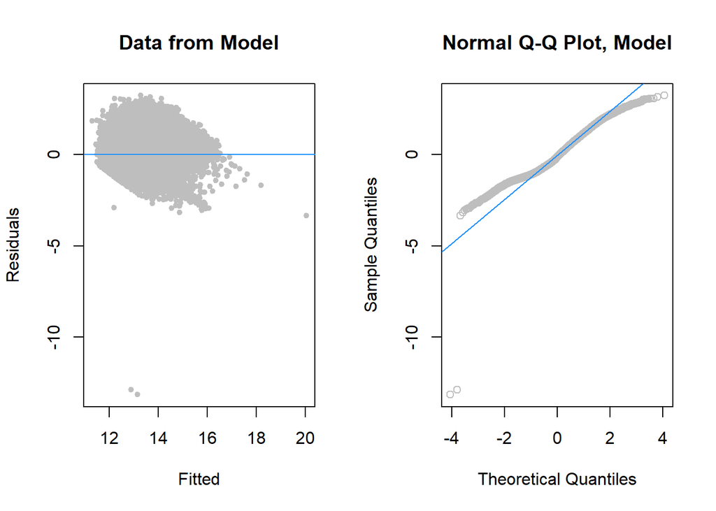

  ```r
  diagnostics(back_aic_log, testit = FALSE)
  ```

- We can attempt to stabilize the variance by applying log transformations to some of the predictors:

  ```r
  #selected_fit = lm(log(salary) ~ yearID + POS + log(GS) + log(PO) + log(E) + log(AB) +
                      #log(H) + log(X2B) + log(X3B) + log(HR) + log(RBI) + log(BB) +
                      #log(SO) + log(IBB) + log(GIDP), data = salary_trn)
  selected_fit = lm(log(salary) ~ yearID + POS + log(GS) + log(PO) + log(E) + log(AB) +
                      log(H) + log(X2B) + log(X3B) + log(HR) + log(RBI) + log(BB) +
                      log(SO) + log(IBB) + log(GIDP) + log(A) + log(DP) + log(HBP) + log(SH) + log(SF), data = salary_trn)
  ```

- After running the diagnostics again, we can see that the variance looks better, but we still have quite a few issues with unusual observations:

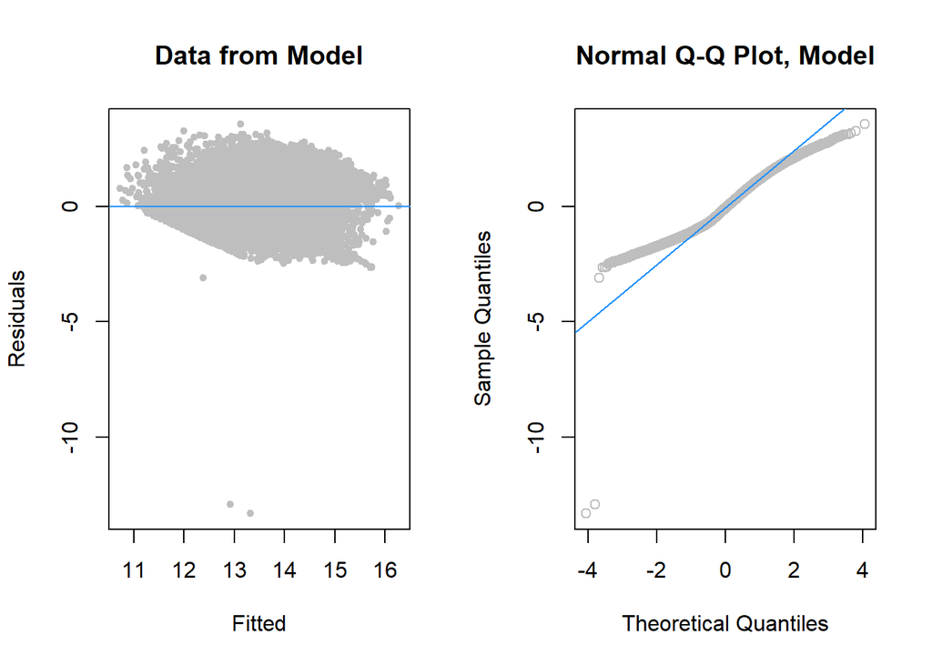

  ```r
  diagnostics(selected_fit, testit = FALSE)
  ```

- We can further refine our model by removing influential outliers. We will use the $D_i > \frac{4}{n}$ Cook’s distance heuristic to identify them:

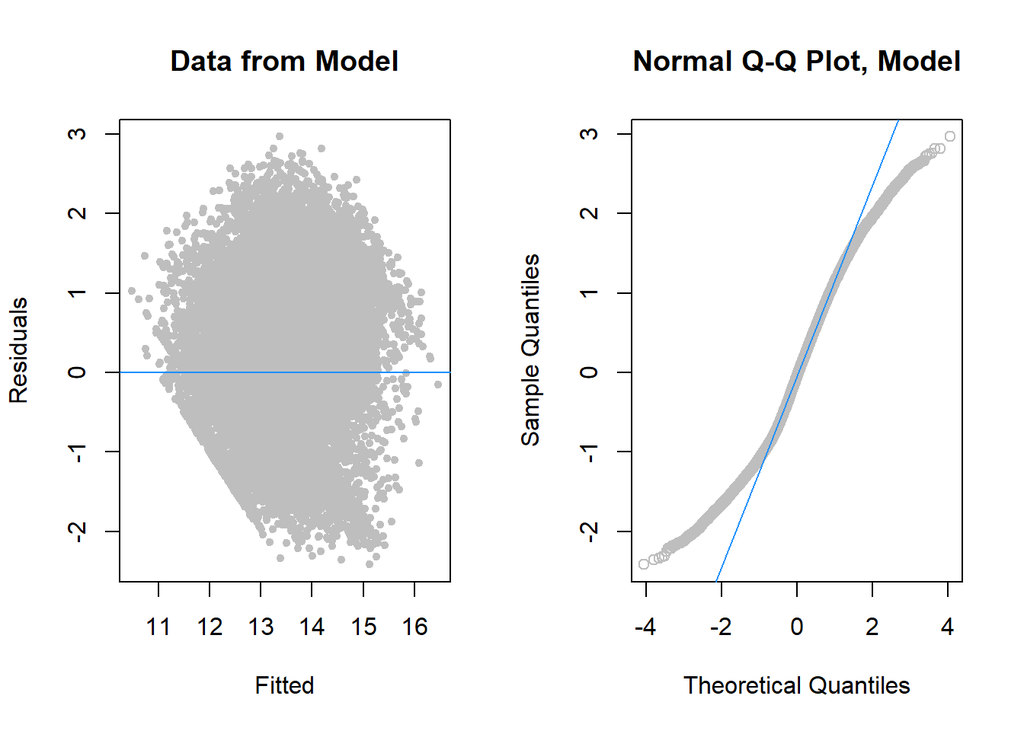

  ```r
  cd_selected = cooks.distance(selected_fit)
  large_cd  = cd_selected > 4 / length(cd_selected)

  selected_fit_fix = lm(log(salary) ~ yearID + POS + log(GS) + log(PO) + log(E) + log(AB) +
                      log(H) + log(X2B) + log(X3B) + log(HR) + log(RBI) + log(BB) +
                      log(SO) + log(IBB) + log(GIDP),
                    subset = -which(large_cd), data = salary_trn)
  diagnostics(selected_fit_fix, testit = FALSE)
  ```

While the model above is looking much better, we will shift our focus on transforming only Fielding and Batting variables in isolation to see if we can improve our Adjusted $R^2$ amd LOOCV RMSE.

We first apply log transformations to the full additive model to variables regarding only batting statistics. Additionally, we will add the interactions between `Year` and `Position`. Finally, we will remove influential outliers to improve our model.

```r
log_fit_batting_selected = lm(log(salary) ~  + yearID * POS * (A + DP + E + GIDP + GS + lgID + log(AB) + log(BB) + log(GIDP) + log(H) + log(HBP) + log(HR) + log(IBB) + log(R) + log(RBI) + log(SF) + log(SH) + log(SO) + log(X2B) + log(X3B) + PO), subset = -which(large_cd), data = salary_trn)
bptest(log_fit_batting_selected)
```

```
##
##  studentized Breusch-Pagan test
##
## data:  log_fit_batting_selected
## BP = 2334, df = 307, p-value < 2.2e-16
```

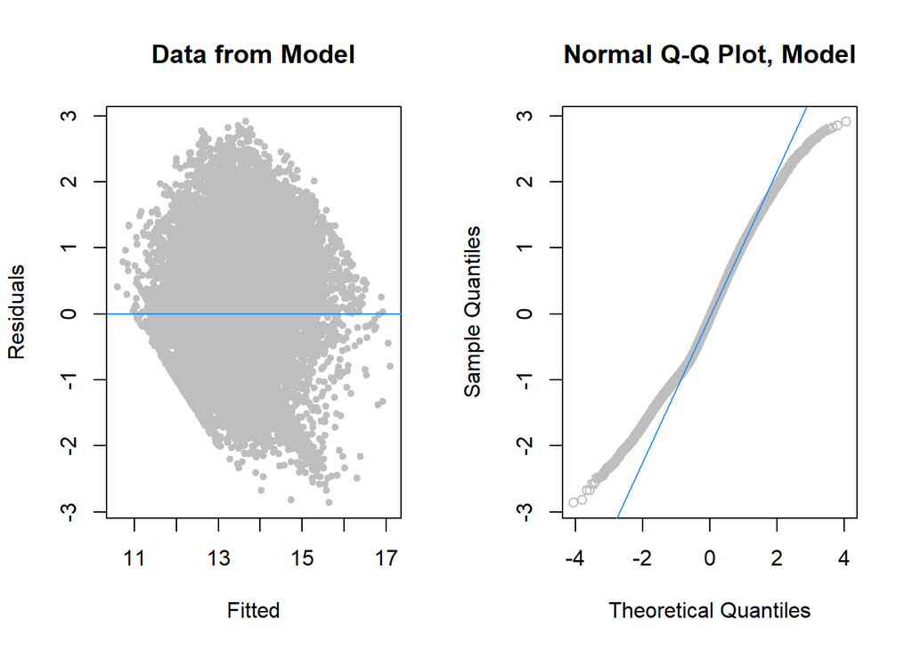

```r
diagnostics(log_fit_batting_selected, testit = FALSE)
```

When we perform the BP test we get a low p-value showing constant variance assumption is violated which matches our findings with the fitted versus residuals plot. When we look at the Q-Q plot it remains similar to the above model where there are still discrepancies.

Likewise, we can apply log transformations to variables regarding fielding statistics to the full additive model and add the `Year` and `POS` interactions.

```r
#log_fit_fielding_selected = lm(log(salary) ~ log(GS) + log(PO) + log(A) + log(E) + log(DP) + . - GS - PO - A - E - DP, subset = -which(large_cd), data = salary_trn)
log_fit_fielding_selected = lm(log(salary) ~ yearID * POS * (AB + BB + GIDP + H + HBP + HR + IBB + lgID + log(A) + log(DP) + log(E) + log(GS) + log(PO) + R + RBI + SF + SH + SO + X2B + X3B), subset = -which(large_cd), data = salary_trn)
bptest(log_fit_fielding_selected)
```

```
##
##  studentized Breusch-Pagan test
##
## data:  log_fit_fielding_selected
## BP = 2356.8, df = 293, p-value < 2.2e-16
```

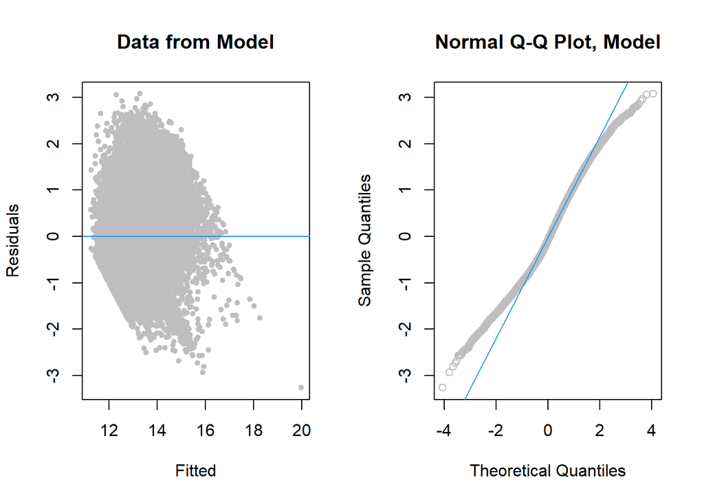

```r
diagnostics(log_fit_fielding_selected, testit = FALSE)
```

We can see adjusting the predictors with log transformations did not make much difference to the assumption violations.

Now, we will compare the adjusted $R^2$ and LOOCV RMSE between our previously chosen AIC model and the two models above.

```r
log_rmse = c(calc_loocv_rmse_log(selected_fit_fix), calc_loocv_rmse_log(log_fit_batting_selected), calc_loocv_rmse_log(log_fit_fielding_selected))

log_rsquared = c(summary(log_fit)$adj.r.squared, summary(log_fit_batting_selected)$adj.r.squared, summary(log_fit_fielding_selected)$adj.r.squared)

log_results = data.frame(Model = c("Backward AIC Log Model", "Batting Selected Log Model", "Fielding Selected Log Model"), AdjR = log_rsquared, RMSE = log_rmse)

kable(log_results,
      col.names = c("Model", "Adjusted R. Squared", "LOOCV RMSE"))
```

| Model | Adjusted R. Squared | LOOCV RMSE |
| --- | --- | --- |
| Backward AIC Log Model | 0.3877166 | 3894.227 |
| Batting Selected Log Model | 0.4483531 | 1322.341 |
| Fielding Selected Log Model | 0.4451254 | 1202.041 |

- Now we can use our test data to compare the average percent error between the models:

  ```r
  predict_aic = exp(predict(selected_fit_fix, newdata = salary_tst))
  predict_batting = exp(predict(log_fit_batting_selected, newdata = salary_tst))
  predict_fielding = exp(predict(log_fit_fielding_selected, newdata = salary_tst))
  n = length(predict_aic)

  (avg_pct_error_aic = (sum(abs(predict_aic - salary_tst$salary) / predict_aic) / n) * 100)
  ```

  ```
  ## [1] 136.9982
  ```

  ```r
  (avg_pct_error_bat = (sum(abs(predict_batting - salary_tst$salary) / predict_batting) / n) * 100)
  ```

  ```
  ## [1] 130.6129
  ```

  ```r
  (avg_pct_error_field = (sum(abs(predict_fielding - salary_tst$salary) / predict_fielding) / n) * 100)
  ```

  ```
  ## [1] 130.7809
  ```

- Calculating the test RMSE for our models:

```r
(aic_rmse = sqrt(mean((predict_aic - salary_tst$salary)^2)))
```

```
## [1] 2948570
```

```r
(batting_rmse = sqrt(mean((predict_batting - salary_tst$salary)^2)))
```

```
## [1] 2828215
```

```r
(fielding_rmse = sqrt(mean((predict_fielding - salary_tst$salary)^2)))
```

```
## [1] 2872596
```

## Results

- Plotting our predicted salaries vs the actual test set salaries:

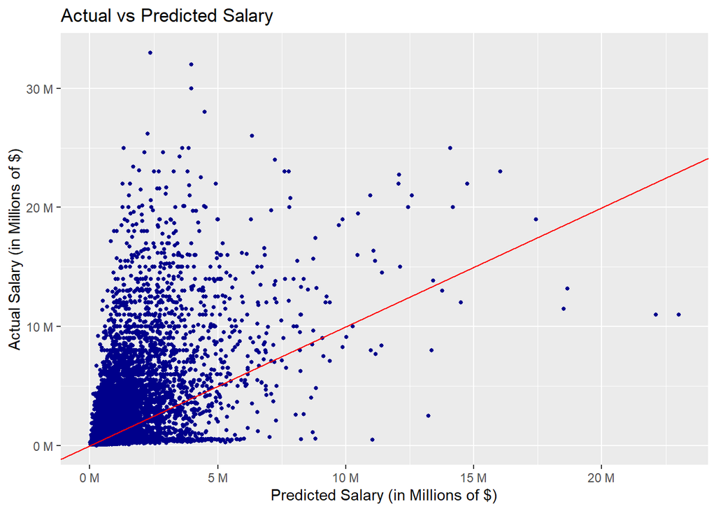

  ```r
  ggplot(data = data.frame(predict_batting, salary_tst$salary), mapping = aes(x = predict_batting, y = salary_tst$salary)) +
    labs(x = "Predicted Salary (in Millions of $)") +
    labs(y = "Actual Salary (in Millions of $)") +
    labs(title = "Actual vs Predicted Salary") +
    geom_point(color = "darkblue", size = 1) +
    scale_y_continuous(labels = label_number(suffix = " M", scale = 1e-6)) +
    scale_x_continuous(labels = label_number(suffix = " M", scale = 1e-6)) +
    geom_abline(slope = 1, intercept = 0, color = "red")
  ```

## Appendix

Team Members: Edgar Hernandez, Ryan Sims, Jessica Tomas

We also created a forward stepwise AIC model, which was the same size as the backward model:

```r
forw_aic = step(simple_fit, direction = "forward", scope = biggest, trace = 0)
summary(forw_aic)$adj.r.squared
```

```
## [1] 0.2707598
```

```r
calc_loocv_rmse(forw_aic)
```

```
## [1] 2793220
```

```r
all.equal(sort(attr(back_aic$terms, "term.labels")), sort(attr(forw_aic$terms, "term.labels")))
```

```
## [1] TRUE
```

Additionally, we took a look at an additive model that takes into account all 2-way interactions and then perform backwards stepwise AIC against that fitted model to arrive at a set of significant coefficients. However, the model took multiple hours to compute and did not achieve desirable results given the extremely large number of variables.

```r
system.time({
  slr3=lm(salary~(.)^2,salary_trn)
})
system.time({
  slr3_AIC=step(slr3,direction='backward', trace=0)
})
summary(slr3)
summary(slr3_AIC)
```

```r
rsquared3 = c(summary(slr3_AIC)$adj.r.squared, summary(slr3)$adj.r.squared)
rmse3 = c(calc_loocv_rmse(slr3_AIC), calc_loocv_rmse(slr3))
aic_results3 = data.frame(Model = c("Backward AIC", "Full Additive with 2-way Interactions"),
                          AdjR = rsquared3, RMSE = rmse3)

kable(aic_results3,
      col.names = c("Selection Procedure", "Adjusted R. Squared", "LOOCV RMSE"))
```

Below are the results we obtained after running the chunk above:

```
|Selection Procedure                   | Adjusted R. Squared| LOOCV RMSE|
|:-------------------------------------|-------------------:|----------:|
|Backward AIC                          |           0.3727780|    2600805|
|Full Additive with 2-way Interactions |           0.3713568|    2624299|
> length(slr3$coefficients)
[1] 364
> length(slr3_AIC$coefficients)
[1] 197
```

We also analyzed log transformations of the predictors without any interactions first:

```r
log_fit_batting_selected = lm(log(salary) ~ log(AB) + log(R) + log(H) + log(X2B) + log(X3B) + log(HR) + log(RBI) + log(BB) + log(SO) + log(IBB) + log(HBP) + log(SH) + log(SF) + log(GIDP) + . - AB - R - H - X2B - X3B - RBI - BB - SO - IBB - HBP - SH - SF, subset = -which(large_cd), data = salary_trn)
```